# Tugas Individu Pertemuan 4 MPDW

Chelsya Putri Ashari-M0401241039

2026-09-15

```r
#install.packages("rmdformats")
```

# LATIHAN PERTEMUAN 4 - PEMBANGKITAN PROSES MA(2), AR(2), DAN ARMA(2,2)

```r
#install.packages("TSA")
library(TSA)
```

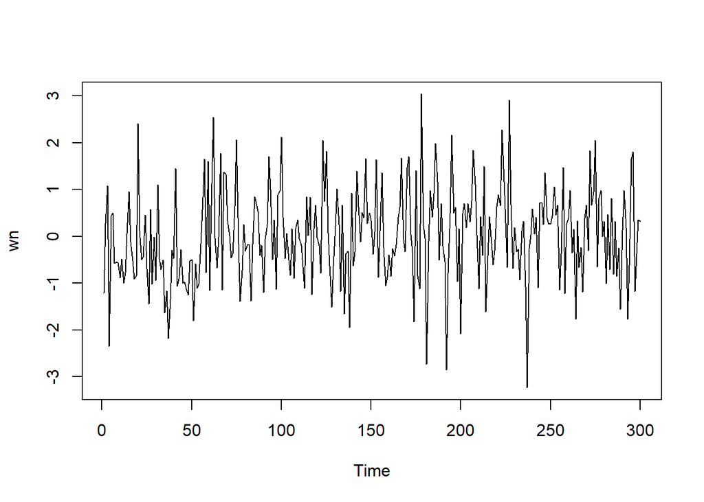

```r
set.seed(1234)
n  <- 300
wn <- rnorm(n)          # white noise sebagai basis pembangkitan semua proses

par(mfrow = c(1, 1))
ts.plot(wn)
```

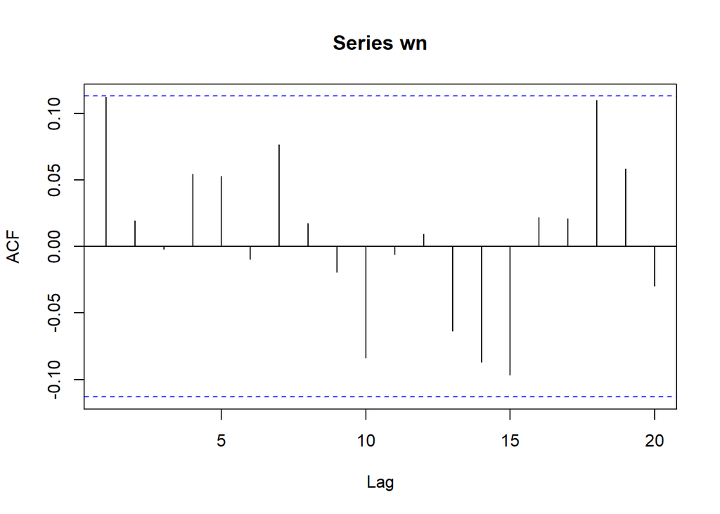

```r
acf(wn, xlim = c(1, 20))
```

# 1. PROSES MA(2) -> theta1 = 0.4 , theta2 = 0.6

Proses MA(2) dapat dituliskan sebagai berikut:

$$Y_t = e_t + \theta_1 e_{t-1} + \theta_2 e_{t-2}$$

## Pembangkitan Data

```r
theta1 <- 0.4
theta2 <- 0.6
```

### Cara Manual

```r
## Model  : Yt = et + theta1*e(t-1) + theta2*e(t-2)
set.seed(1234)
ma2 <- wn[1:2]
for (i in 3:n) {
  ma2[i] <- wn[i] + theta1 * wn[i - 1] + theta2 * wn[i - 2]
}
ma2
```

```
##   [1] -1.207065749  0.277429242  0.471173424 -1.745463687  0.141510314
##   [6] -0.729712854 -0.114842790 -0.472894305 -1.127948717 -1.443797742
##  [11] -1.171879031 -1.723286222 -1.461924092 -0.845074607  0.519525249
##  [16]  0.312187420  0.020572732 -1.181770516 -1.508255550  1.534249256
##  [21]  0.598119283  1.012450498 -0.556369299 -0.011041246 -0.774213194
##  [26] -1.449939345 -0.420758391 -1.662676381 -0.079747157 -1.556197355
##  [31]  0.718835126 -0.596243221 -0.238298741 -1.070389923 -2.255260716
##  [36] -2.120011486 -3.624543435 -2.913580609 -2.138714925 -1.388210999
##  [41]  1.086560934 -0.768382742 -0.413123964 -1.263954490 -1.619808057
##  [46] -1.534624150 -2.091327966 -2.276021753 -1.689013389 -1.457572736
##  [51] -2.319068111 -1.602598402 -2.425338748 -1.807763414 -1.233628102
##  [56] -0.110845196  1.775654086  0.223607057  2.285258743 -0.979456751
##  [61]  1.157010823  2.116941328  1.378789117  0.845856907 -0.296314421
##  [66]  1.372262398 -0.432336811  1.978634754  1.193531021  1.688995021
##  [71]  0.939220832 -0.250827924 -0.544575725  0.228395751  2.109671129
```

[output cut: 45 more lines]

### Menggunakan arima.sim()

```r
set.seed(1234)
ma2.sim <- arima.sim(list(order = c(0, 0, 2), ma = c(theta1, theta2)), n = n)
ma2.sim
```

```
## Time Series:
## Start = 1
## End = 300
## Frequency = 1
##   [1]  0.471173424 -1.745463687  0.141510314 -0.729712854 -0.114842790
##   [6] -0.472894305 -1.127948717 -1.443797742 -1.171879031 -1.723286222
##  [11] -1.461924092 -0.845074607  0.519525249  0.312187420  0.020572732
##  [16] -1.181770516 -1.508255550  1.534249256  0.598119283  1.012450498
##  [21] -0.556369299 -0.011041246 -0.774213194 -1.449939345 -0.420758391
##  [26] -1.662676381 -0.079747157 -1.556197355  0.718835126 -0.596243221
##  [31] -0.238298741 -1.070389923 -2.255260716 -2.120011486 -3.624543435
##  [36] -2.913580609 -2.138714925 -1.388210999  1.086560934 -0.768382742
##  [41] -0.413123964 -1.263954490 -1.619808057 -1.534624150 -2.091327966
##  [46] -2.276021753 -1.689013389 -1.457572736 -2.319068111 -1.602598402
##  [51] -2.425338748 -1.807763414 -1.233628102 -0.110845196  1.775654086
```

[output cut: 49 more lines]

## Plot Time Series, ACF, PACF, EACF

### Plot Time Series

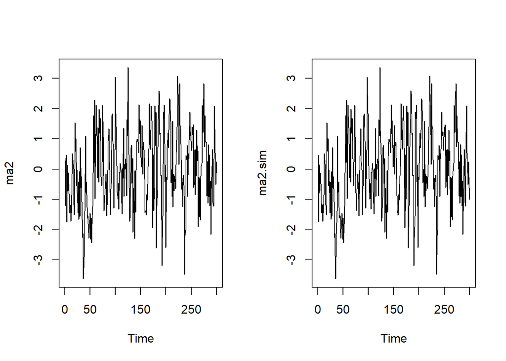

```r
par(mfrow = c(1, 2))
ts.plot(ma2);     ts.plot(ma2.sim)
```

```r
par(mfrow = c(1, 1))
```

Berdasarkan plot time series tersebut, terlihat bahwa data MA(2) yang dibangkitkan berfluktuasi di sekitar nilai tengah tertentu sehingga cenderung **stasioner dalam rataan**.

### Plot ACF

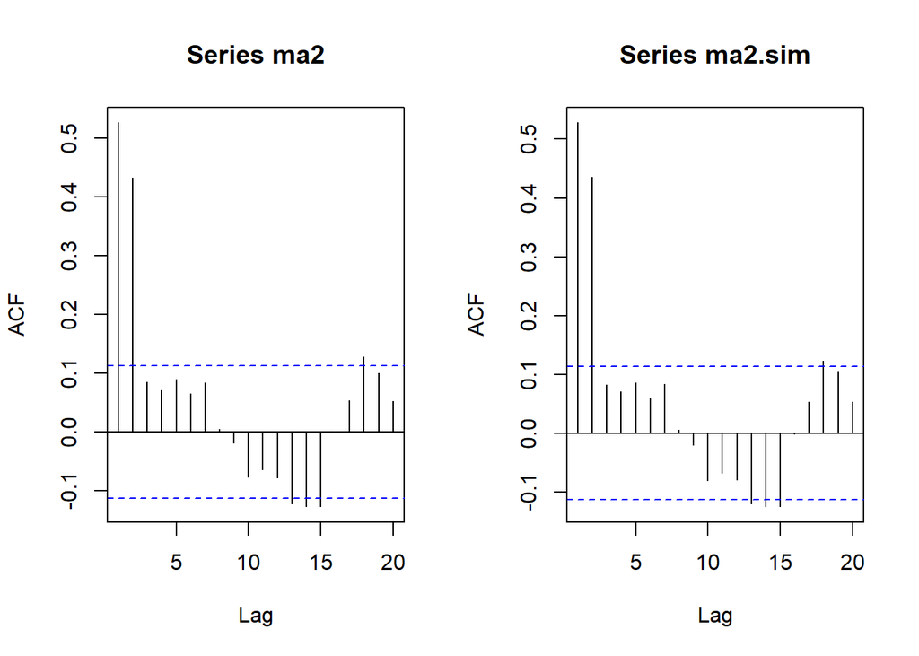

```r
par(mfrow = c(1, 2))
acf(ma2,     lag.max = 20)
acf(ma2.sim, lag.max = 20)
```

```r
par(mfrow = c(1, 1))
```

Berdasarkan plot ACF tersebut, terlihat bahwa plot ACF **cuts off** setelah lag ke-2, sesuai dengan teori proses MA(2).

### Plot PACF

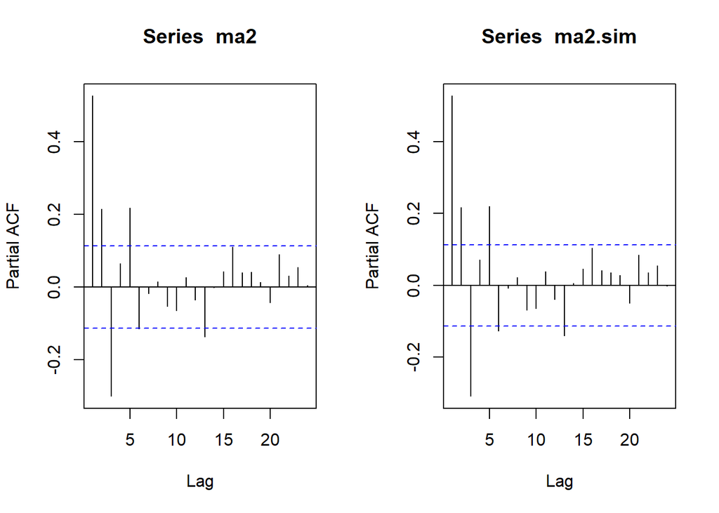

```r
par(mfrow = c(1, 2))
pacf(ma2)
pacf(ma2.sim)
```

```r
par(mfrow = c(1, 1))
```

Berdasarkan plot PACF tersebut, terlihat bahwa plot PACF cenderung **tails off** membentuk pola gelombang sinus.

### Plot EACF

```r
TSA::eacf(ma2)
```

```
## AR/MA
##   0 1 2 3 4 5 6 7 8 9 10 11 12 13
## 0 x x o o o o o o o o o  o  x  x
## 1 x x x o o o o o o o o  o  o  o
## 2 x x x x o o o o o o o  o  o  o
## 3 x x x x x o o o o o o  o  o  o
## 4 x x x x x o o o o o o  o  o  o
## 5 x x x x x o x o o o o  o  o  o
## 6 x x x o x o o x o o o  o  o  o
## 7 x o x o x o o x o o o  o  o  o
```

```r
TSA::eacf(ma2.sim)
```

```
## AR/MA
##   0 1 2 3 4 5 6 7 8 9 10 11 12 13
## 0 x x o o o o o o o o o  o  x  x
## 1 x x x o o o o o o o o  o  o  o
## 2 x x x x o o o o o o o  o  o  o
## 3 x x x x o o o o o o o  o  o  o
## 4 x x x x o o o o o o o  o  o  o
## 5 x x o x x o x o o o o  o  o  o
## 6 o x o o x o o x o o o  o  o  o
## 7 x o x o x o o x o o o  o  o  o
```

Berdasarkan pola segitiga nol pada plot EACF, terlihat bahwa segitiga nol berada pada ordo AR(0) dan ordo MA(2), sesuai dengan model yang dibangkitkan.

## Scatterplot antar lag: Yt vs Yt-1, Yt vs Yt-2, Yt vs Yt-3

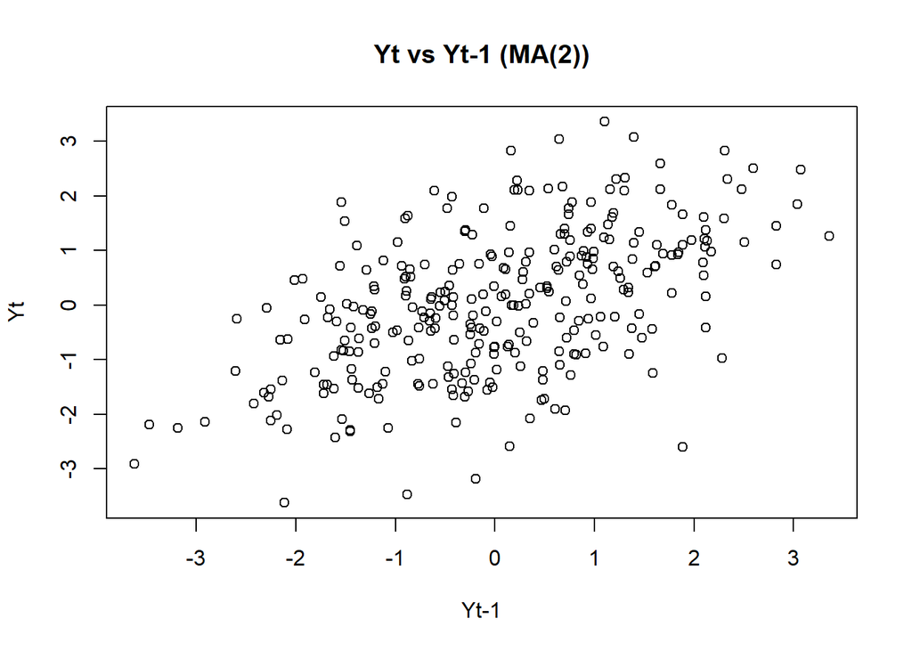

```r
# Yt vs Yt-1
yt_ma2    <- ma2[-1]
yt_1_ma2  <- ma2[-n]
plot(y = yt_ma2, x = yt_1_ma2,
     main = "Yt vs Yt-1 (MA(2))", xlab = "Yt-1", ylab = "Yt")
```

```r
cor(yt_ma2, yt_1_ma2)
```

```
## [1] 0.5274606
```

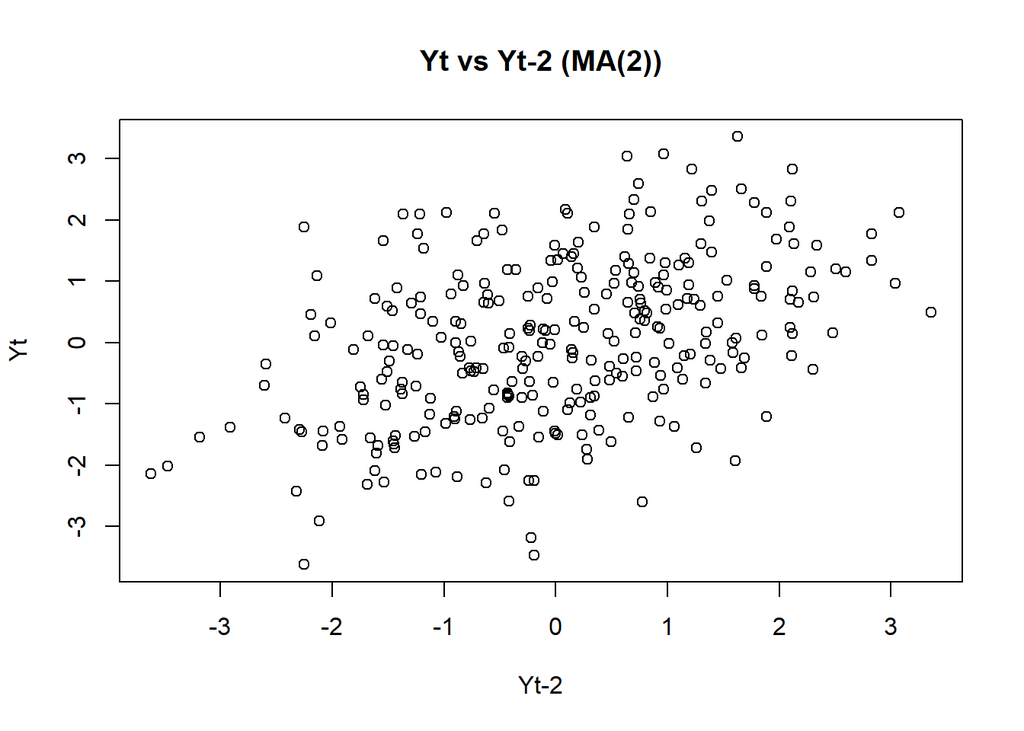

```r
# Yt vs Yt-2
yt_ma2_2   <- ma2[-c(1, 2)]
yt_2_ma2   <- ma2[-c(n - 1, n)]
plot(y = yt_ma2_2, x = yt_2_ma2,
     main = "Yt vs Yt-2 (MA(2))", xlab = "Yt-2", ylab = "Yt")
```

```r
cor(yt_ma2_2, yt_2_ma2)
```

```
## [1] 0.4339293
```

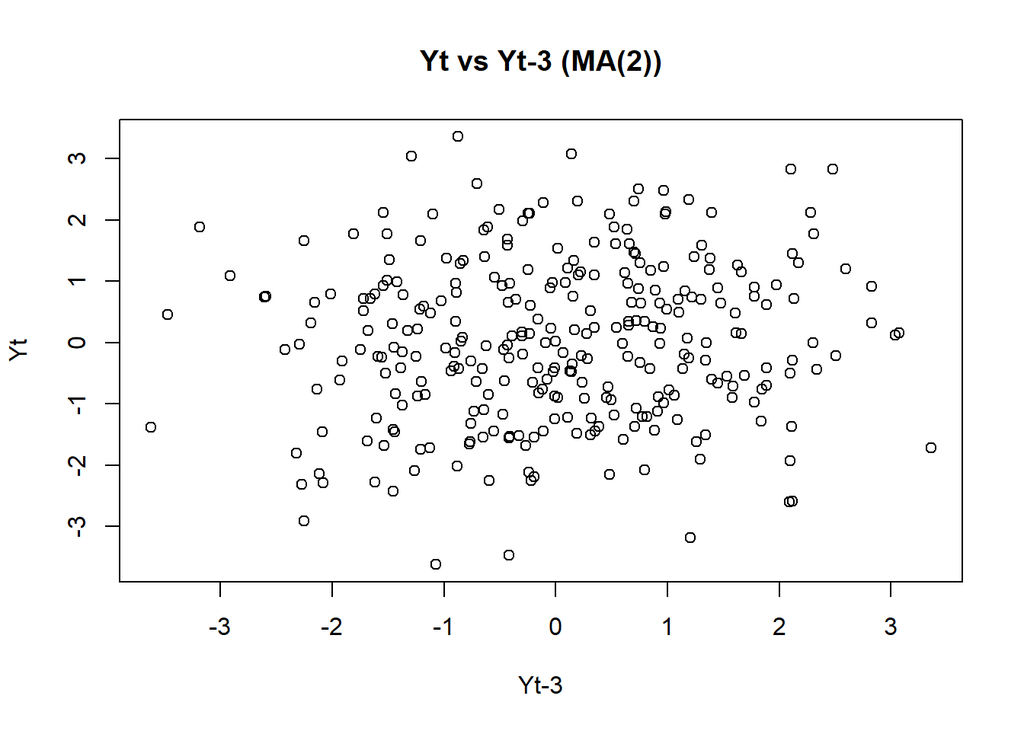

```r
# Yt vs Yt-3
yt_ma2_3   <- ma2[-c(1, 2, 3)]
yt_3_ma2   <- ma2[-c(n - 2, n - 1, n)]
plot(y = yt_ma2_3, x = yt_3_ma2,
     main = "Yt vs Yt-3 (MA(2))", xlab = "Yt-3", ylab = "Yt")
```

```r
cor(yt_ma2_3, yt_3_ma2)
```

```
## [1] 0.08555282
```

Terlihat bahwa hubungan antara $Y_t$ dengan $Y_{t-1}$ dan $Y_{t-2}$ masih cukup kuat, sedangkan hubungan antara $Y_t$ dengan $Y_{t-3}$ cenderung tidak ada, sesuai dengan sifat MA(2) yang hanya memiliki autokorelasi signifikan hingga lag ke-2.

## Autokorelasi: hasil bangkitan vs teoritis

Untuk model $Y_t = e_t + \theta_1 e_{t-1} + \theta_2 e_{t-2}$, autokorelasi teoritisnya adalah:

$$\rho_1 = \frac{\theta_1 + \theta_1\theta_2}{1+\theta_1^2+\theta_2^2}
\qquad
\rho_2 = \frac{\theta_2}{1+\theta_1^2+\theta_2^2}
\qquad
\rho_k = 0 \; ,\; k \ge 3$$

```r
denom_ma2 <- 1 + theta1^2 + theta2^2
rho1_ma2_teori <- (theta1 + theta1 * theta2) / denom_ma2
rho2_ma2_teori <- theta2 / denom_ma2
rho3_ma2_teori <- 0

cat("=== Autokorelasi MA(2) ===\n")
```

```
## === Autokorelasi MA(2) ===
```

```r
cat("Empiris  rho1 :", cor(yt_ma2, yt_1_ma2),     "\n")
```

```
## Empiris  rho1 : 0.5274606
```

```r
cat("Teoritis rho1 :", rho1_ma2_teori, "\n\n")
```

```
## Teoritis rho1 : 0.4210526
```

```r
cat("Empiris  rho2 :", cor(yt_ma2_2, yt_2_ma2),   "\n")
```

```
## Empiris  rho2 : 0.4339293
```

```r
cat("Teoritis rho2 :", rho2_ma2_teori, "\n\n")
```

```
## Teoritis rho2 : 0.3947368
```

```r
cat("Empiris  rho3 :", cor(yt_ma2_3, yt_3_ma2),   "\n")
```

```
## Empiris  rho3 : 0.08555282
```

```r
cat("Teoritis rho3 :", rho3_ma2_teori, "\n\n")
```

```
## Teoritis rho3 : 0
```

```r
ARMAacf(ma = c(theta1, theta2), lag.max = 5)
```

```
##         0         1         2         3         4         5
## 1.0000000 0.4210526 0.3947368 0.0000000 0.0000000 0.0000000
```

Nilai autokorelasi hasil bangkitan mendekati nilai teoritis, khususnya untuk lag 1 dan 2, sementara autokorelasi lag 3 mendekati nol.

# 2. PROSES AR(2) -> phi1 = 0.5 , phi2 = 0.2

Proses AR(2) dapat dituliskan sebagai berikut:

$$Y_t = \phi_1 Y_{t-1} + \phi_2 Y_{t-2} + e_t$$

## Pembangkitan Data

```r
phi1 <- 0.5
phi2 <- 0.2
```

### Cara Manual

Model : Yt = phi1*Y(t-1) + phi2*Y(t-2) + et

```r
set.seed(1234)
ar2 <- wn[1:2]                       # dua nilai awal
for (i in 3:n) {
  ar2[i] <- phi1 * ar2[i - 1] + phi2 * ar2[i - 2] + wn[i]
}
ar2
```

```
##   [1] -1.207065749  0.277429242  0.981742648 -1.799340530 -0.274197047
##   [6]  0.009089263 -0.625034738 -0.857331372 -1.118124633 -1.620566420
##  [11] -1.511100836 -2.078050147 -2.117499135 -1.409900780 -0.168956158
##  [16] -0.476743729 -0.783172602 -1.398130464 -1.692871432  1.289773370
##  [21]  0.440400618 -0.012530914 -0.358733205  0.277716656 -0.626608560
##  [26] -1.705965859 -0.403548921 -1.566623355 -0.879159762 -1.688853153
##  [31]  0.082039017 -0.772344201 -1.079204335 -1.195329068 -2.442598870
##  [36] -2.627984511 -3.982551678 -3.857865933 -3.019737161 -2.747339308
##  [41] -0.528120821 -1.882170996 -1.902074296 -1.608094349 -2.178802110
##  [46] -2.379534243 -2.732845736 -3.094315602 -2.617555067 -2.424490611
##  [51] -3.541787576 -2.837867835 -3.236181057 -3.200626105 -2.409858787
##  [56] -1.281998796  0.524846317 -0.767330024  1.327213880 -0.647667612
##  [61]  0.598197434  2.718556265  1.444157230  0.596156288  0.579304834
##  [66]  2.185968123  0.070237292  1.840139450  2.263681974  1.836341674
##  [71]  1.377800070  0.600699632  0.209385897  0.873119442  2.548707762
```

[output cut: 45 more lines]

### Menggunakan arima.sim()

```r
set.seed(1234)
ar2.sim <- arima.sim(list(order = c(2, 0, 0), ar = c(phi1, phi2)), n = n)
ar2.sim
```

```
## Time Series:
## Start = 1
## End = 300
## Frequency = 1
##   [1] -1.7066325607 -0.4040571790 -1.5670108246 -0.8794551485 -1.6890783403
##   [6]  0.0818673463 -0.7724750738 -1.0793041051 -1.1954051279 -2.4426568541
##  [11] -2.6280287147 -3.9825853771 -3.8578916236 -3.0197567460 -2.7473542381
##  [16] -0.5281322030 -1.8821796728 -1.9020809107 -1.6080993919 -2.1788059544
##  [21] -2.3795371734 -2.7328479702 -3.0943173054 -2.6175563658 -2.4244916012
##  [26] -3.5417883306 -2.8378684102 -3.2361814957 -3.2006264394 -2.4098590424
##  [31] -1.2819989901  0.5248461693 -0.7673301373  1.3272137941 -0.6476676781
##  [36]  0.5981973841  2.7185562271  1.4441572006  0.5961562661  0.5793048174
##  [41]  2.1859681101  0.0702372818  1.8401394423  2.2636819683  1.8363416698
##  [46]  1.3778000670  0.6006996293  0.2093858952  0.8731194410  2.5487077608
##  [51]  1.2955793561 -0.2331697165 -0.5810507641 -0.0788975632 -0.4727180494
```

[output cut: 49 more lines]

## Plot Time Series, ACF, PACF, EACF

### Plot Time Series

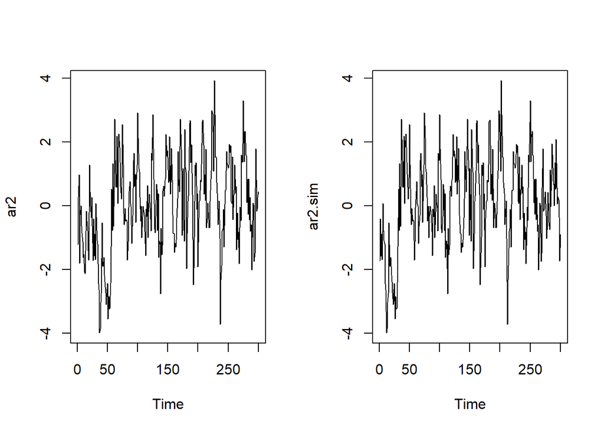

```r
par(mfrow = c(1, 2))
ts.plot(ar2);     ts.plot(ar2.sim)
```

```r
par(mfrow = c(1, 1))
```

Berdasarkan plot time series tersebut, terlihat bahwa data cenderung **stasioner dalam rataan** karena $\phi_1+\phi_2 = 0.7 < 1$ (akar karakteristik berada di luar lingkaran satuan).

### Plot ACF

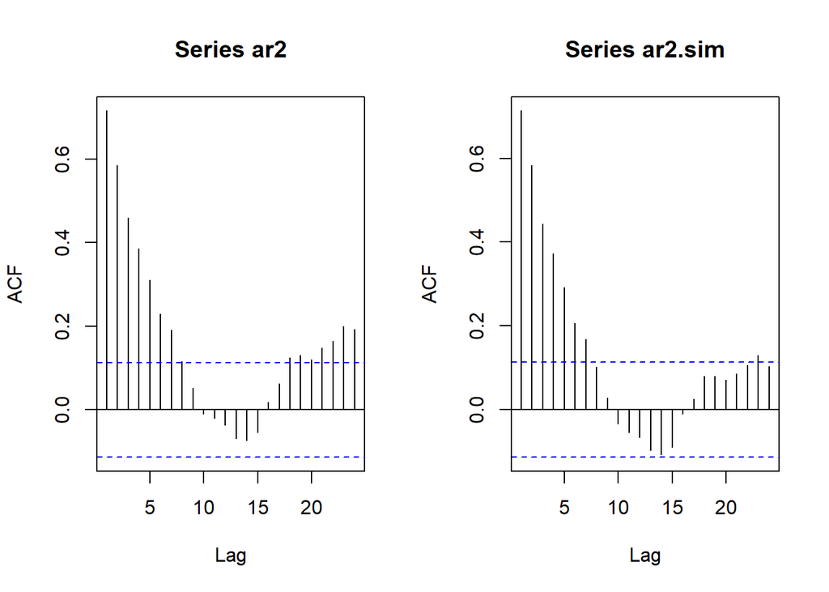

```r
par(mfrow = c(1, 2))
acf(ar2)
acf(ar2.sim)
```

```r
par(mfrow = c(1, 1))
```

Berdasarkan plot ACF tersebut, terlihat bahwa plot ACF cenderung **tails off** membentuk pola grafik menurun/sinusoidal.

### Plot PACF

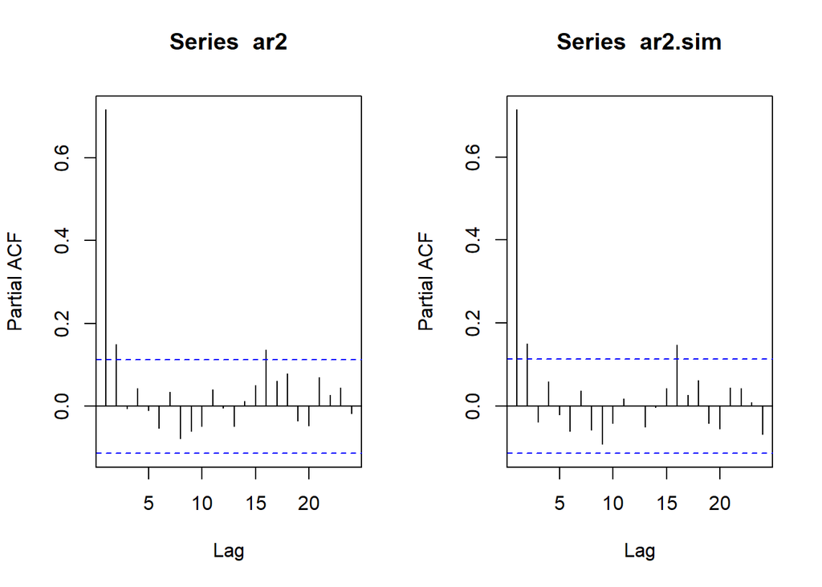

```r
par(mfrow = c(1, 2))
pacf(ar2)
pacf(ar2.sim)
```

```r
par(mfrow = c(1, 1))
```

Berdasarkan plot PACF tersebut, terlihat bahwa plot PACF **cuts off** setelah lag ke-2, sesuai dengan teori proses AR(2).

### Plot EACF

```r
TSA::eacf(ar2)
```

```
## AR/MA
##   0 1 2 3 4 5 6 7 8 9 10 11 12 13
## 0 x x x x x x x o o o o  o  o  o
## 1 x o o o o o o o o o o  o  o  o
## 2 o o o o o o o o o o o  o  o  o
## 3 x x o o o o o o o o o  o  o  o
## 4 x x o o o o o o o o o  o  o  o
## 5 x x o x o o x o o o o  o  o  o
## 6 x x x x o o o o o o o  o  o  o
## 7 x x x o x x o o o o o  o  o  o
```

```r
TSA::eacf(ar2.sim)
```

```
## AR/MA
##   0 1 2 3 4 5 6 7 8 9 10 11 12 13
## 0 x x x x x x x o o o o  o  o  o
## 1 x o o o o o o o o o o  o  o  o
## 2 x o o o o o o o o o o  o  o  o
## 3 x x o o o o o o o o o  o  o  o
## 4 x x o o o o o o o o o  o  o  o
## 5 x x x o o o o o o o o  o  o  o
## 6 x x x o o o o o o o o  o  o  o
## 7 x x x o x x o o o o o  o  o  o
```

## Scatterplot antar lag: Yt vs Yt-1, Yt vs Yt-2, Yt vs Yt-3

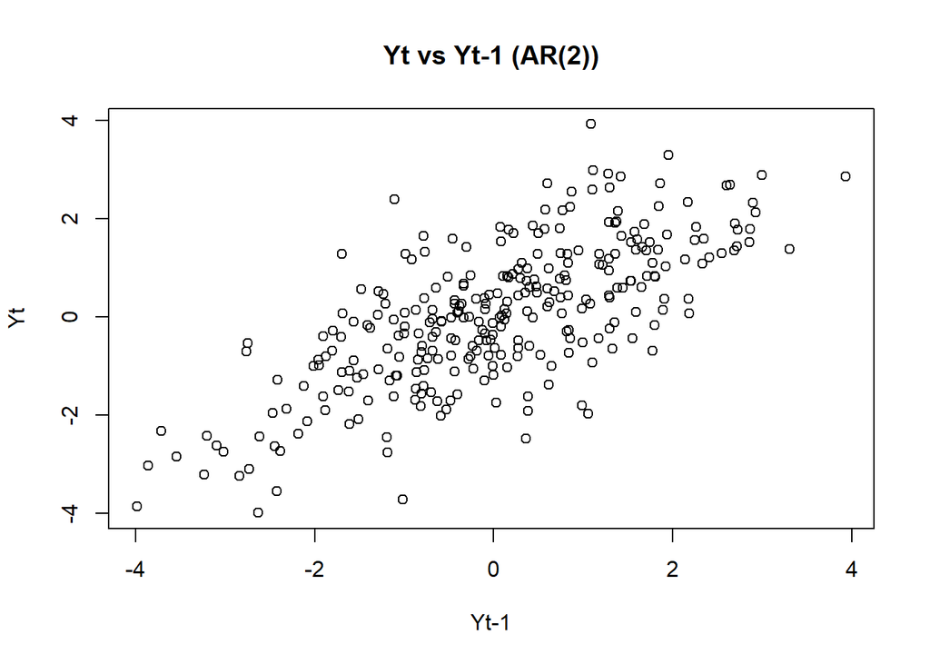

```r
# Yt vs Yt-1
yt_ar2    <- ar2[-1]
yt_1_ar2  <- ar2[-n]
plot(y = yt_ar2, x = yt_1_ar2,
     main = "Yt vs Yt-1 (AR(2))", xlab = "Yt-1", ylab = "Yt")
```

```r
cor(yt_ar2, yt_1_ar2)
```

```
## [1] 0.7165728
```

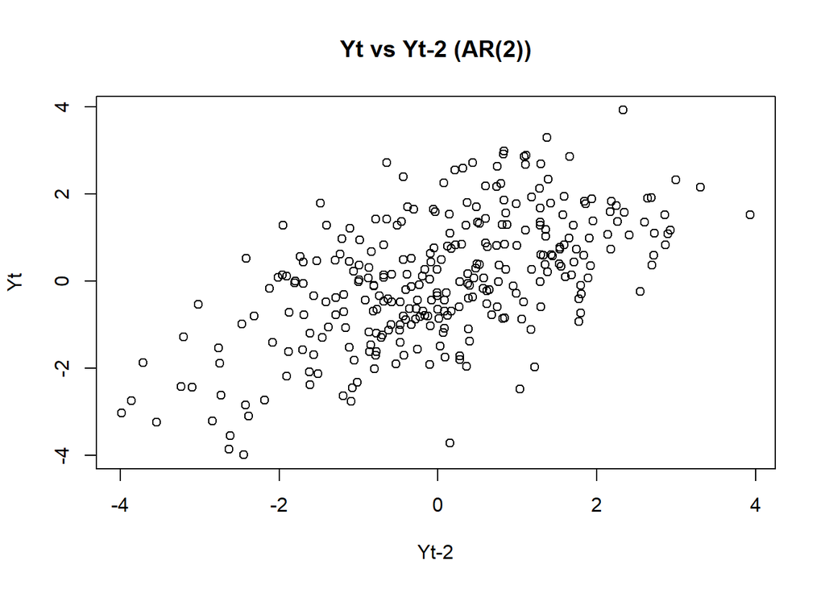

```r
# Yt vs Yt-2
yt_ar2_2   <- ar2[-c(1, 2)]
yt_2_ar2   <- ar2[-c(n - 1, n)]
plot(y = yt_ar2_2, x = yt_2_ar2,
     main = "Yt vs Yt-2 (AR(2))", xlab = "Yt-2", ylab = "Yt")
```

```r
cor(yt_ar2_2, yt_2_ar2)
```

```
## [1] 0.5856318
```

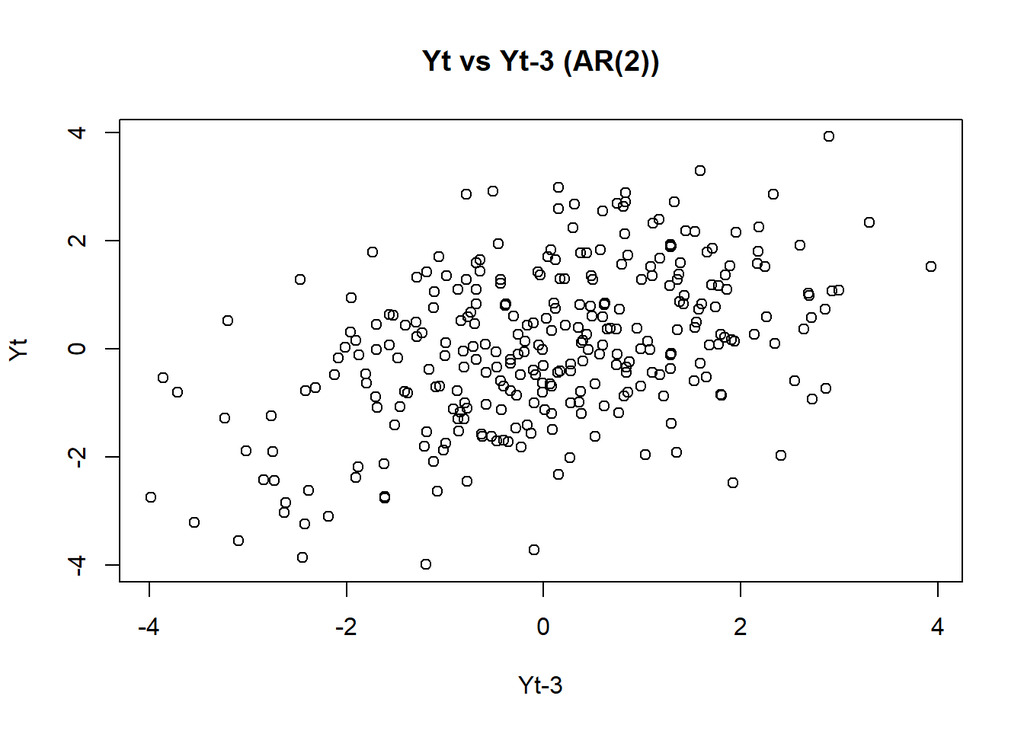

```r
# Yt vs Yt-3
yt_ar2_3   <- ar2[-c(1, 2, 3)]
yt_3_ar2   <- ar2[-c(n - 2, n - 1, n)]
plot(y = yt_ar2_3, x = yt_3_ar2,
     main = "Yt vs Yt-3 (AR(2))", xlab = "Yt-3", ylab = "Yt")
```

```r
cor(yt_ar2_3, yt_3_ar2)
```

```
## [1] 0.4609517
```

Terlihat bahwa terdapat hubungan positif antara $Y_t$ dengan $Y_{t-1}$, $Y_{t-2}$, maupun $Y_{t-3}$, namun kekuatan hubungannya semakin melemah seiring bertambahnya lag, sesuai dengan sifat proses AR yang autokorelasinya meluruh (tails off) secara bertahap.

## Autokorelasi: hasil bangkitan vs teoritis

Untuk model $Y_t = \phi_1 Y_{t-1} + \phi_2 Y_{t-2} + e_t$, autokorelasi teoritisnya diperoleh dari persamaan Yule-Walker:

$$\rho_1 = \frac{\phi_1}{1-\phi_2}
\qquad
\rho_2 = \phi_2 + \frac{\phi_1^2}{1-\phi_2}
\qquad
\rho_k = \phi_1\rho_{k-1}+\phi_2\rho_{k-2} \; ,\; k \ge 3$$

```r
rho1_ar2_teori <- phi1 / (1 - phi2)
rho2_ar2_teori <- phi2 + (phi1^2) / (1 - phi2)
rho3_ar2_teori <- phi1 * rho2_ar2_teori + phi2 * rho1_ar2_teori

cat("=== Autokorelasi AR(2) ===\n")
```

```
## === Autokorelasi AR(2) ===
```

```r
cat("Empiris  rho1 :", cor(yt_ar2, yt_1_ar2),     "\n")
```

```
## Empiris  rho1 : 0.7165728
```

```r
cat("Teoritis rho1 :", rho1_ar2_teori, "\n\n")
```

```
## Teoritis rho1 : 0.625
```

```r
cat("Empiris  rho2 :", cor(yt_ar2_2, yt_2_ar2),   "\n")
```

```
## Empiris  rho2 : 0.5856318
```

```r
cat("Teoritis rho2 :", rho2_ar2_teori, "\n\n")
```

```
## Teoritis rho2 : 0.5125
```

```r
cat("Empiris  rho3 :", cor(yt_ar2_3, yt_3_ar2),   "\n")
```

```
## Empiris  rho3 : 0.4609517
```

```r
cat("Teoritis rho3 :", rho3_ar2_teori, "\n\n")
```

```
## Teoritis rho3 : 0.38125
```

```r
ARMAacf(ar = c(phi1, phi2), lag.max = 5)
```

```
##         0         1         2         3         4         5
## 1.0000000 0.6250000 0.5125000 0.3812500 0.2931250 0.2228125
```

# 3. PROSES ARMA(2,2) -> phi1 = 0.5, phi2 = 0.2, theta1 = 0.4, theta2 = 0.6

Proses ARMA(2,2) dapat dituliskan sebagai berikut:

$$Y_t = \phi_1 Y_{t-1} + \phi_2 Y_{t-2} + e_t + \theta_1 e_{t-1} +
\theta_2 e_{t-2}$$

## Pembangkitan Data

### Cara Manual

Model : Yt = phi1*Y(t-1) + phi2*Y(t-2) + et + theta1*e(t-1) + theta2*e(t-2)

```r
set.seed(1234)
arma22 <- wn[1:2]                    # dua nilai awal
for (i in 3:n) {
  arma22[i] <- phi1 * arma22[i - 1] + phi2 * arma22[i - 2] +
               theta1 * wn[i - 1]    + theta2 * wn[i - 2]  + wn[i]
}
arma22
```

```
##   [1] -1.20706575  0.27742924  0.36847490 -1.50574039 -0.53766490 -1.29969338
##   [7] -0.87222246 -1.16894421 -1.88686532 -2.62101924 -2.85976172 -3.67737093
##  [13] -3.87256190 -3.51682974 -2.01340200 -1.39787953 -1.08104743 -2.00187014
##  [19] -2.72540011 -0.22882482 -0.06137315  0.93599896 -0.10064445  0.12583632
##  [25] -0.73142392 -1.79048404 -1.46228520 -2.75191579 -1.74816209 -2.98066156
##  [31] -1.12112807 -1.75293957 -1.33899414 -2.09047491 -3.56829700 -4.32225497
##  [37] -6.49933032 -7.02769676 -6.95242937 -6.26996504 -3.43890746 -3.74182948
##  [43] -2.97182019 -3.49823048 -3.96328734 -4.21591391 -4.99194239 -5.61517573
##  [49] -5.49498973 -5.32810275 -6.08211743 -5.70927767 -6.49640107 -6.19781948
##  [55] -5.63181806 -4.16631812 -1.43386859 -1.32659086  1.33518960 -0.57718012
##  [61]  1.13545868  2.56923464  2.89049817  2.80495292  1.68426167  2.77538382
##  [67]  1.29220743  3.17981523  3.04188012  3.84589813  3.47054592  2.25362466
##  [73]  1.27634579  1.31729358  3.02358708  2.83893413  1.81428668  0.10302896
##  [79] -0.45121970 -0.85290753 -0.66635425 -0.93510416 -2.14779642 -2.08562341
##  [85] -1.51503473 -0.24121274  0.91556687  0.64537308  0.48311177 -1.14217407
```

[output cut: 35 more lines]

### Menggunakan arima.sim()

```r
set.seed(1234)
arma22.sim <- arima.sim(list(order = c(2, 0, 2),
                              ar = c(phi1, phi2),
                              ma = c(theta1, theta2)), n = n)
arma22.sim
```

```
## Time Series:
## Start = 1
## End = 300
## Frequency = 1
##   [1] -2.75189059 -1.74814288 -2.98064692 -1.12111691 -1.75293106 -1.33898765
##   [7] -2.09046996 -3.56829323 -4.32225209 -6.49932813 -7.02769509 -6.95242810
##  [13] -6.26996407 -3.43890672 -3.74182891 -2.97181976 -3.49823015 -3.96328709
##  [19] -4.21591372 -4.99194225 -5.61517562 -5.49498965 -5.32810268 -6.08211738
##  [25] -5.70927763 -6.49640104 -6.19781946 -5.63181804 -4.16631811 -1.43386858
##  [31] -1.32659085  1.33518960 -0.57718012  1.13545868  2.56923465  2.89049818
##  [37]  2.80495292  1.68426168  2.77538382  1.29220743  3.17981524  3.04188012
##  [43]  3.84589813  3.47054592  2.25362466  1.27634579  1.31729358  3.02358708
##  [49]  2.83893413  1.81428668  0.10302896 -0.45121970 -0.85290753 -0.66635425
##  [55] -0.93510416 -2.14779642 -2.08562341 -1.51503473 -0.24121274  0.91556687
##  [61]  0.64537308  0.48311177 -1.14217407 -1.12039092 -1.27141453  0.91636167
```

[output cut: 39 more lines]

## Plot Time Series, ACF, PACF, EACF

### Plot Time Series

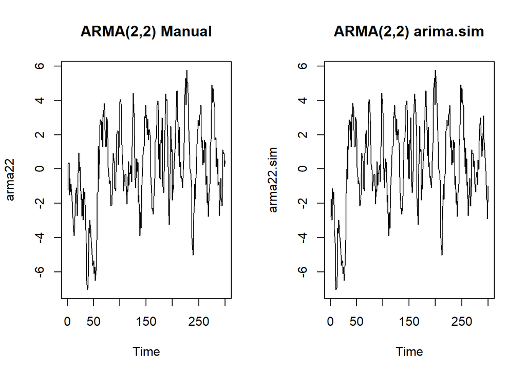

```r
par(mfrow = c(1, 2))
ts.plot(arma22, main = "ARMA(2,2) Manual")
ts.plot(arma22.sim, main = "ARMA(2,2) arima.sim")
```

```r
par(mfrow = c(1, 1))
```

Berdasarkan plot time series tersebut, terlihat bahwa model ARMA(2,2) cenderung **stasioner dalam rataan**.

### Plot ACF

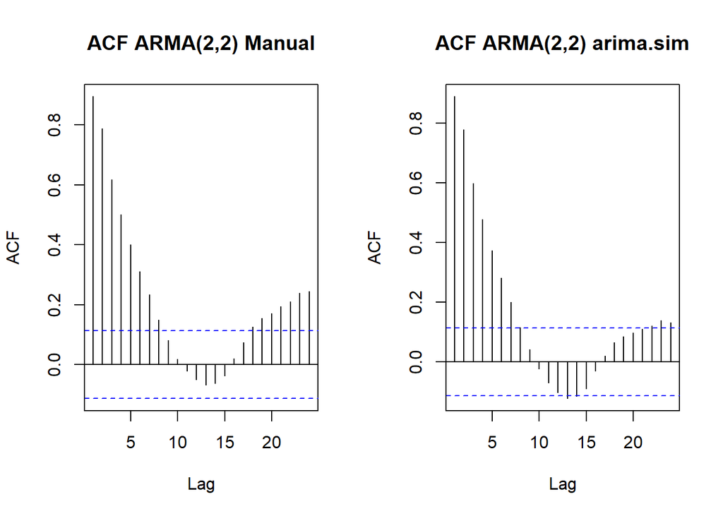

```r
par(mfrow = c(1, 2))
acf(arma22, main = "ACF ARMA(2,2) Manual")
acf(arma22.sim, main = "ACF ARMA(2,2) arima.sim")
```

```r
par(mfrow = c(1, 1))
```

Berdasarkan plot ACF tersebut, terlihat bahwa model ARMA(2,2) hasil simulasi memiliki plot ACF yang **tails off**, sesuai dengan teori yang ada.

### Plot PACF

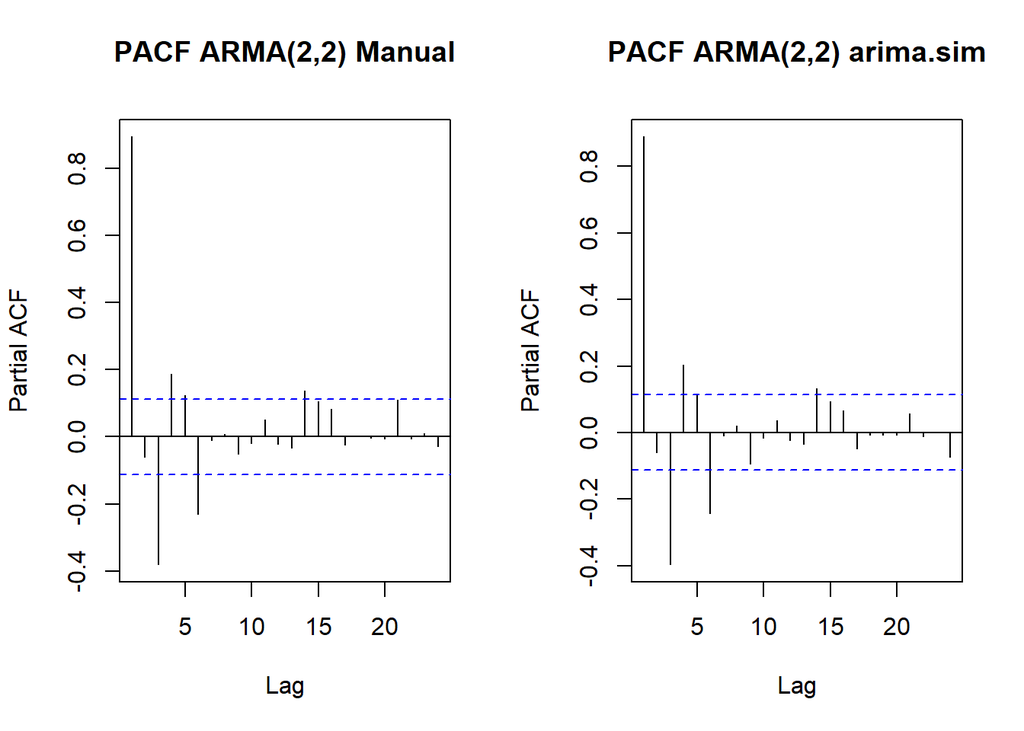

```r
par(mfrow = c(1, 2))
pacf(arma22, main = "PACF ARMA(2,2) Manual")
pacf(arma22.sim, main = "PACF ARMA(2,2) arima.sim")
```

```r
par(mfrow = c(1, 1))
```

### Plot EACF

```r
TSA::eacf(arma22)
```

```
## AR/MA
##   0 1 2 3 4 5 6 7 8 9 10 11 12 13
## 0 x x x x x x x x o o o  o  o  o
## 1 o x o o o o x o o o o  o  o  o
## 2 x x o o o o x o o o o  o  o  o
## 3 x x o x o o x o o o o  o  o  o
## 4 x x x x o o x o o o o  o  o  o
## 5 x x x x x x x o o o o  o  o  o
## 6 o o x o x x o o o o o  o  o  o
## 7 o o x o x x o x o o o  o  o  o
```

```r
TSA::eacf(arma22.sim)
```

```
## AR/MA
##   0 1 2 3 4 5 6 7 8 9 10 11 12 13
## 0 x x x x x x x o o o o  o  x  o
## 1 o x o o o o x o o o o  o  o  o
## 2 x x o o o o o o o o o  o  o  o
## 3 x x x x o o o o o o o  o  o  o
## 4 x x x x o o o o o o o  o  o  o
## 5 x x x x x x x o o o o  o  o  o
## 6 o o x o x x o o o o o  o  o  o
## 7 x o x x x x o x o o o  o  o  o
```

Berdasarkan pola segitiga nol pada plot EACF, terlihat bahwa segitiga nol berada pada ordo AR(2) dan ordo MA(2), sesuai dengan model yang dibangkitkan.

## Scatterplot Antar Lag

### Korelasi antara $Y_t$ dengan $Y_{t-1}$

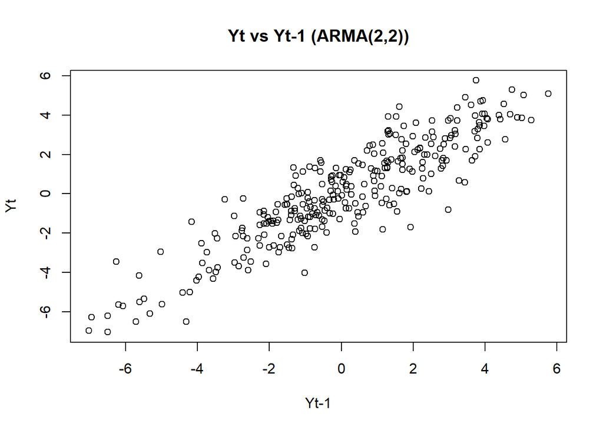

```r
yt_arma22   <- arma22[-1]
yt_1_arma22 <- arma22[-n]
plot(y = yt_arma22, x = yt_1_arma22, xlab = "Yt-1", ylab = "Yt",
     main = "Yt vs Yt-1 (ARMA(2,2))")
```

```r
cor(yt_arma22, yt_1_arma22)
```

```
## [1] 0.8946787
```

### Korelasi antara $Y_t$ dengan $Y_{t-2}$

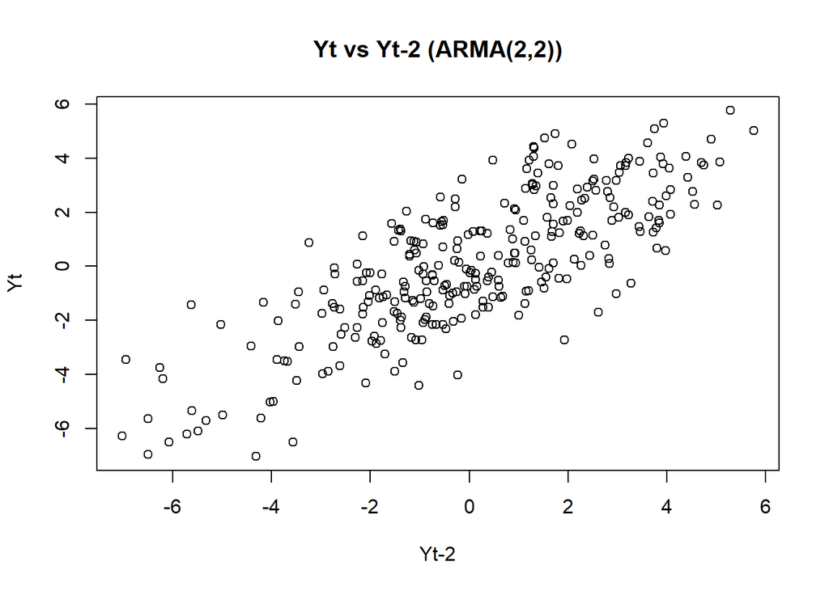

```r
yt_arma22_2 <- arma22[-c(1, 2)]
yt_2_arma22 <- arma22[-c(n - 1, n)]
plot(y = yt_arma22_2, x = yt_2_arma22, xlab = "Yt-2", ylab = "Yt",
     main = "Yt vs Yt-2 (ARMA(2,2))")
```

```r
cor(yt_arma22_2, yt_2_arma22)
```

```
## [1] 0.78822
```

### Korelasi antara $Y_t$ dengan $Y_{t-3}$

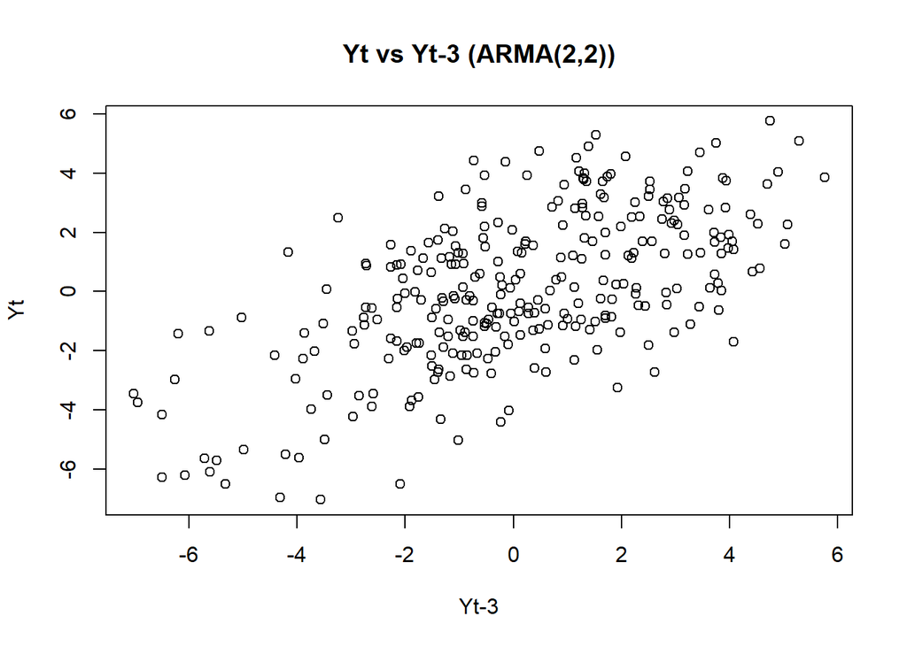

```r
yt_arma22_3 <- arma22[-c(1, 2, 3)]
yt_3_arma22 <- arma22[-c(n - 2, n - 1, n)]
plot(y = yt_arma22_3, x = yt_3_arma22, xlab = "Yt-3", ylab = "Yt",
     main = "Yt vs Yt-3 (ARMA(2,2))")
```

```r
cor(yt_arma22_3, yt_3_arma22)
```

```
## [1] 0.6177423
```

Berdasarkan scatterplot tersebut, terlihat bahwa terdapat hubungan antara $Y_t$ dengan lag-lag sebelumnya, dengan kekuatan hubungan yang meluruh mengikuti pola komponen AR-nya. Hal ini sesuai dengan teori yang ada.

## Autokorelasi: Data Bangkitan vs Teoritis

Untuk model ARMA(2,2), penurunan rumus tertutup $\rho_k$ melibatkan penyelesaian sistem persamaan Yule-Walker yang diperluas dengan komponen MA sehingga cukup panjang. Nilai teoritisnya dihitung secara praktis menggunakan fungsi bawaan `ARMAacf()`, yang menghitung ACF teoritis murni dari parameter model (bukan dari data bangkitan).

```r
rho_teori_arma22 <- ARMAacf(ar = c(phi1, phi2),
                             ma = c(theta1, theta2),
                             lag.max = 3)
rho_teori_arma22
```

```
##         0         1         2         3
## 1.0000000 0.8591993 0.7491908 0.5464353
```

```r
cat("Empiris  rho1 :", cor(yt_arma22, yt_1_arma22),   "| Teoritis rho1 :", rho_teori_arma22[1], "\n")
```

[output not shown]

```r
cat("Empiris  rho2 :", cor(yt_arma22_2, yt_2_arma22), "| Teoritis rho2 :", rho_teori_arma22[2], "\n")
```

```
## Empiris  rho2 : 0.78822 | Teoritis rho2 : 0.8591993
```

```r
cat("Empiris  rho3 :", cor(yt_arma22_3, yt_3_arma22), "| Teoritis rho3 :", rho_teori_arma22[3], "\n")
```

```
## Empiris  rho3 : 0.6177423 | Teoritis rho3 : 0.7491908
```

Nilai autokorelasi hasil bangkitan mendekati nilai teoritis dari `ARMAacf()`, menunjukkan bahwa proses simulasi ARMA(2,2) sudah sesuai dengan model yang ditetapkan.

# Kesimpulan

| Proses | Parameter | Pola ACF | Pola PACF | Kestasioneran |
| --- | --- | --- | --- | --- |
| MA(2) | $\theta_1=0.4,\ \theta_2=0.6$ | Cuts off lag 2 | Tails off | Stasioner |
| AR(2) | $\phi_1=0.5,\ \phi_2=0.2$ | Tails off | Cuts off lag 2 | Stasioner |
| ARMA(2,2) | $\phi_1=0.5,\phi_2=0.2,\theta_1=0.4,\theta_2=0.6$ | Tails off | Tails off | Stasioner |

Ketiga proses yang dibangkitkan (MA(2), AR(2), ARMA(2,2)) menunjukkan pola ACF/PACF yang sesuai dengan teori masing-masing model, dan nilai autokorelasi hasil bangkitan (baik manual maupun `arima.sim()`) mendekati nilai autokorelasi teoritisnya.